# Figure S12 – CMAP pattern x trait LDSC enrichment dot plot

Partitioned-heritability enrichment of the 3 spatial-transcriptomics patterns for cerebellar / cognitive GWAS traits

2026-09-10 11:26:43

# Overview

LDSC partitioned-heritability enrichment of the three CoGAPS spatial-transcriptomics patterns against cerebellar-imaging and cognitive GWAS traits. **Dot colour = coefficient Z-score** (red–blue, −5…5); **dot size = −log10(FDR)**. Only significant associations (**FDR < 0.05**) are shown, matching the deck’s curated view (3 patterns × 5 traits).

Data: `Supplementary_Datasets/Data_S3_SpatialTx_Tables.xlsx` (sheet `ldsc_results_cogaps`; from the lab GitHub repo, LDSC pipeline — `source_from_github/`). The full result across all patterns/traits is in that table; here we plot the deck’s subset.

# Data + subset

```r
dat <- readxl::read_excel(find_s12("Data_S3_SpatialTx_Tables.xlsx"), sheet = "ldsc_results_cogaps")

# deck subset: 3 patterns, 5 traits (map the GWAS trait IDs to the deck's short labels)
pattern_map <- c(Pattern_27 = "CMAP_PCL", Pattern_17 = "CMAP_IGL", Pattern_16 = "CMAP_IGL_IMM")
trait_map <- c(
 "Tissink 2022 - Cerebellar Volume" = "Cerebellar volume",
 "UKB_IDP_0148_IDP_T1_FAST_ROIs_V_cerebellum_crus_II" = "Cerebellum crus II",
 "UKB_IDP_0151_IDP_T1_FAST_ROIs_V_cerebellum_VIIb" = "Cerebellum VIIb",
 "Davies reaction time" = "Reaction time",
 "Chambers_total_cerebellar_volume" = "Total cerebellar volume")

PATTERN_ORDER <- c("CMAP_PCL", "CMAP_IGL_IMM", "CMAP_IGL") # top -> bottom (deck)
TRAIT_ORDER <- c("Cerebellar volume", "Cerebellum crus II", "Cerebellum VIIb",
 "Reaction time", "Total cerebellar volume") # left -> right (deck)

df <- dat %>%
 filter(cell %in% names(pattern_map), trait %in% names(trait_map)) %>%
 mutate(pattern = factor(pattern_map[cell], levels = rev(PATTERN_ORDER)), # rev -> CMAP_PCL on top
 trait = factor(trait_map[trait], levels = TRAIT_ORDER),
 coef_z = `Coefficient_z.score`,
 neglog10FDR = -log10(FDR)) %>%
 filter(FDR < 0.05) # significant only (deck)
knitr::kable(df %>% select(pattern, trait, coef_z, FDR) %>% arrange(pattern, trait), digits = 3,
 caption = "Significant (FDR<0.05) pattern x trait associations shown in the plot")
```

Significant (FDR<0.05) pattern x trait associations shown in the plot

| pattern | trait | coef_z | FDR |
| --- | --- | --- | --- |
| CMAP_IGL | Reaction time | 3.289 | 0.048 |
| CMAP_IGL_IMM | Reaction time | 3.782 | 0.021 |
| CMAP_PCL | Cerebellar volume | 3.669 | 0.026 |
| CMAP_PCL | Cerebellum crus II | 3.926 | 0.015 |
| CMAP_PCL | Cerebellum VIIb | 4.046 | 0.015 |
| CMAP_PCL | Total cerebellar volume | 3.392 | 0.039 |

# Figure S12 – dot plot

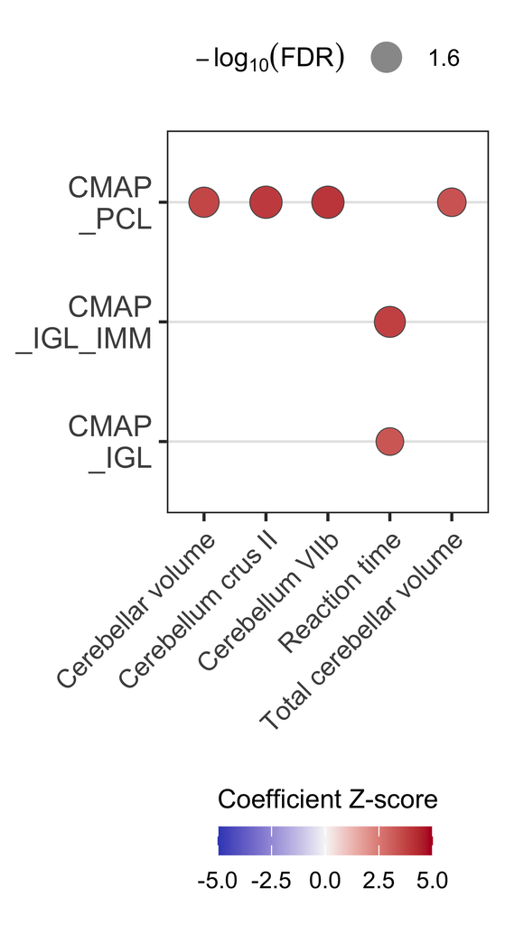

```r
p <- ggplot(df, aes(trait, pattern)) +
 geom_point(aes(size = neglog10FDR, fill = coef_z), shape = 21, colour = "grey35", stroke = 0.25) +
 scale_fill_gradient2(low = "#3B4CC0", mid = "#F7F7F7", high = "#B40426",
 midpoint = 0, limits = c(-5, 5), breaks = c(-5, -2.5, 0, 2.5, 5),
 name = "Coefficient Z-score") +
 scale_size_area(name = expression(-log[10](FDR)), max_size = 5, breaks = 1.6) +
 scale_y_discrete(labels = function(x) sub("_", "\n_", x)) + # two-line row labels (CMAP\n_PCL)
 labs(x = NULL, y = NULL) +
 theme_bw(base_size = 11) +
 theme(panel.grid.minor = element_blank(),
 panel.grid.major.x = element_blank(),
 panel.grid.major.y = element_line(colour = "grey90", linewidth = 0.4),
 axis.text.x = element_text(angle = 45, hjust = 1, size = 9),
 axis.text.y = element_text(size = 10),
 legend.title = element_text(size = 9), legend.text = element_text(size = 8)) +
 guides(
 size = guide_legend(position = "top", title.position = "left",
 override.aes = list(fill = "grey60", colour = "grey60")),
 fill = guide_colourbar(position = "bottom", title.position = "top",
 barwidth = unit(2.6, "cm"), barheight = unit(0.35, "cm")))
print(p)
```

```r
ggsave("Figure_S12_Pattern_Trait_Dotplot.pdf", p, width = 2.4, height = 4.4, device = cairo_pdf, bg = "white")
```

# Provenance

Source: **lab GitHub** `kratimenoslab/Human-Preterm-Cerebellum` → `LDSC/enrichment_analysis/project_cogaps/` (`plot_ldsc_enrichment.R`, `ldsc_results_cogaps.csv`); reference code in `source_from_github/`, data consolidated here as `Supplementary_Datasets/Data_S3_SpatialTx_Tables.xlsx` (sheet `ldsc_results_cogaps`). Patterns: Pattern_27=CMAP_PCL, Pattern_17=CMAP_IGL, Pattern_16=CMAP_IGL_IMM. FDR is precomputed in the table (`p.adjust` of the coefficient z-score p-values across all pattern×trait tests). We plot the deck’s curated subset (these 3 patterns × 5 cerebellar/cognitive traits, FDR<0.05).